# Vaccine solidarity

9/8/2021

## Questions

## Questions

- What is the willingness to share $ and vaccines with countries in need
- Is willingness driven by:
  - Strategic considerations (home benefits)
  - Strategic considerations (global collective actions problems)
  - Non-strategic considerations (humanitarian concerns)
- Is willingness sensitive to interventions?

## Answers

- Relatively high willingness to share: average $ willingness is “enough”; median is somewhat short of this
- Concerns over economic and health implications for Germany matter, on the margin
- Collective action considerations less prominent
- Humanitarian considerations seem central
- Willingness is sensitive to interventions

## Background

## Needs

- *Massive* global inequity in distributions
- Health and especially economic implications for global south countries is very large
- Not only morally problematic but strategically short sighted given *global* health and economic risks

## Who is vaccinated?

Country distributions by wealth

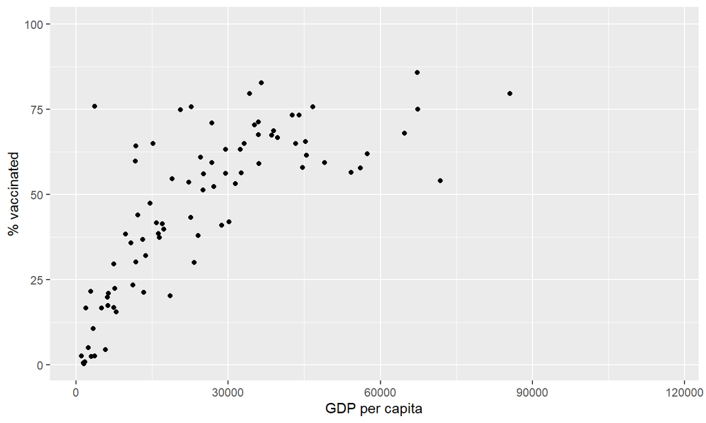

## Who is vaccinated?

Country distributions by burden

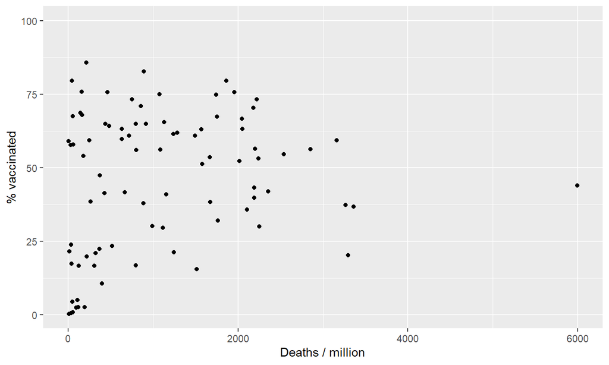

## Ballpark Numbers

- Vaccines needed: 10 - 12 billion (6b made; 5bn needed) (WHO)
- Cash needed, ca 70 - 150 billion
- ACT-Accelerator strategy calls for US$ 23.4 for most at risk
- German ODA: US$28.4 billion in 2020 (OECD DAC)
- Global costs: $9 trillion (Agarwall et al), additional: $ 5.3 trillion (Unicef)
- German “fair share” ca $5b (OECD/Care approach)
- German COVAX contribution $1b
- Future needs unknown given mutation risks

## Design

## Dimensions

\(2 \times 2 \times 5\) factorial design:

**Two costs dimensions**

- *Settings* in which there are public health benefits for Germany
- *Settings* in which there are economic growth implications for Germany.

e.g. “Say it were known that rhe risk of new mutations of the coronavirus increases considerably in Germany if there are no vaccinations in poorer countries”

## Dimensions

\(2 \times 2 \times 5\) factorial design:

**Two coordination dimensions**

Imagine settings in which:

- 0 / 20 / 40 countries took part,
- contributing collectively 0 / 20 / 40 billion euros

## Dimensions

Note:

- There is no attempt to *alter beliefs* about costs or coordination.
- These are *conditional questions*

## Design

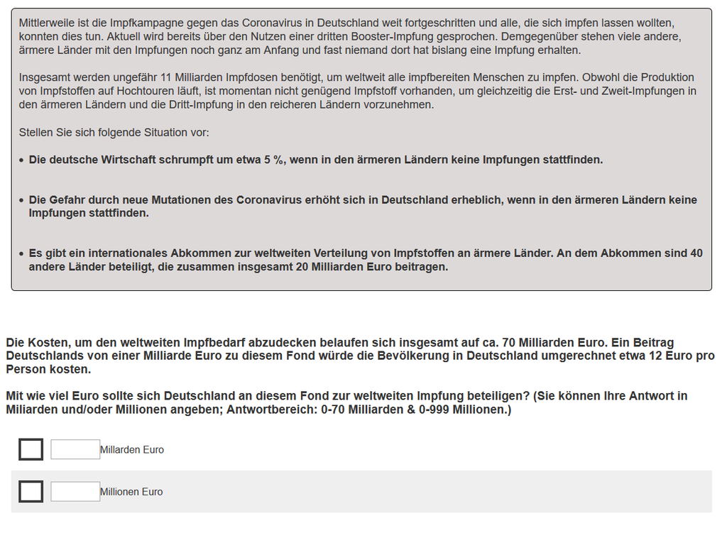

Variants

## Framing

Subjects are asked about amounts of vaccines that Germany should share and financial contributions Germany should make in each condition.

Outcome 1:

> The total costs to meet global vaccination needs amount to around 70 billion euros.

> A contribution from Germany of one billion euros to this fund would cost the population in Germany the equivalent of around 12 euros per person.

> For each of the two scenarios, please indicate how many euros Germany should contribute to this fund for global vaccination. (Options range from 0 to 70 billion; Millions can be specified, separated by commas (e.g.~0.1 billion for 100 million))

## Framing

Subjects are asked about amounts of vaccines that Germany should share and financial contributions Germany should make in each condition.

Outcome 2:

> Germany will still have around 200 million vaccine doses available by the end of the year. If Germany wanted to offer all of its citizens a third vaccination, Germany would have to reserve around 70 million of these vaccine doses.

## Results

## Main results

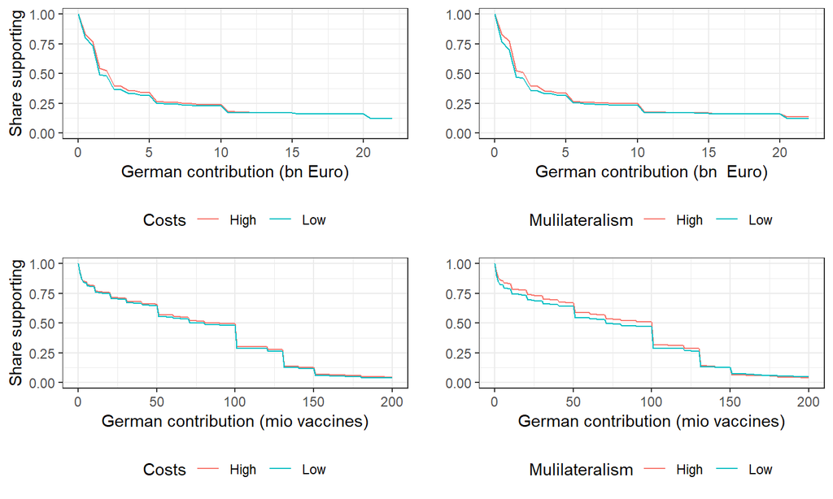

## Main results

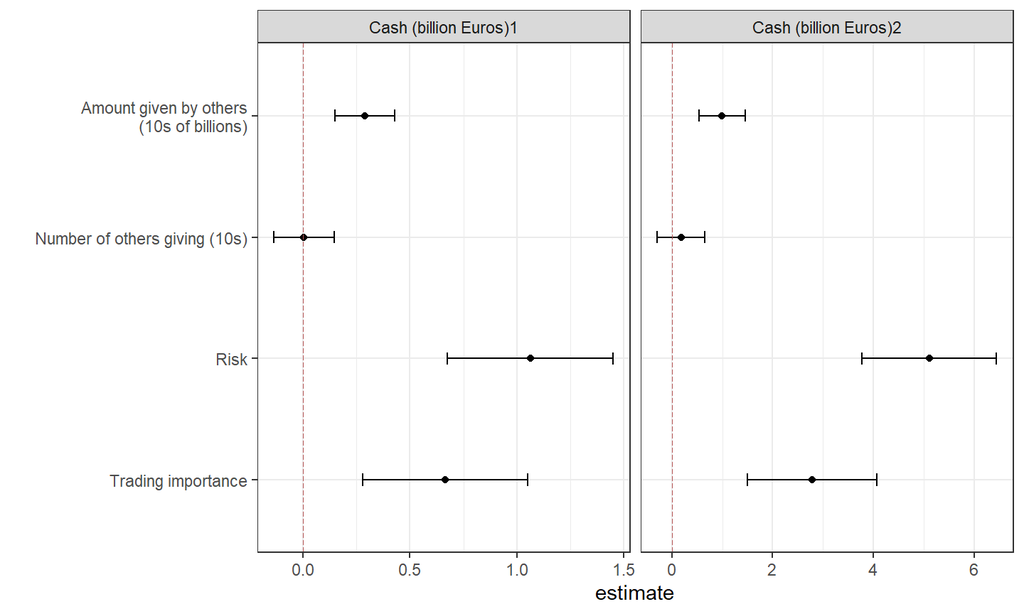

- Note complementarity in giving and invariance to numbers of other countries

## Treatment effects

A video treatment exposed 50% of subjects (in wave 2) to information on the global health gains from global vaccine distribution.

Attitudinal and behavioral outcome (donate share of earnings to UNICEF; approx share of $1)

## Treatment effects

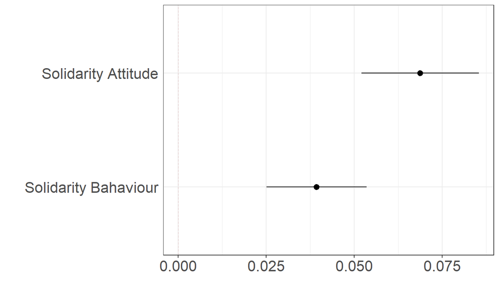

## Direct evidence for humanitarian concern?

We ask subjects to indicate how much a young German woman and an older Indian woman should be prioritized for vaccinations.

We think strategic considerations dominate for the German woman, but humanitarian considerations for the Indian woman.

## Direct evidence for humanitarian concern?

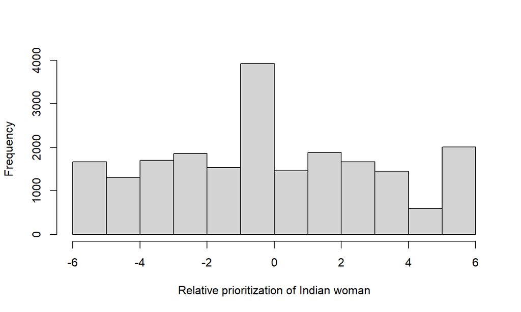

## Discussion

## Caveats

- methodological caveat regarding framing; plausibly quite sensitive to this
- methodological caveat regarding hypotheticals; not a field setting and so in a sense only as good as respondents’ imaginations

## Substantive

- Benefits from major investments likely much higher than traditional ODA; regardless, excellent value for money
- Germany is contributing well *comparatively* but can do more
- Bottom line is that levels of generosity and willingness to engage are quite high: the political support is there
- Paper focuses on dollars and doses but other strsategies also: sharing intellectual property and know-how